# 2017-01-23-intro-rstudio-rmarkdown

2017-01-18

## Today's topics

- Introduction to [RStudio](http://rstudio.com)
- Introduction to R Markdown

## [RStudio](http://rstudio.com)

- An integrated development environment (IDE) for R

## Components of RStudio

- Code editor
- R console
- Integrated help
- Image viewer
- Integration with git and other version-control packages
- Project management

## RStudio in the cloud

- RStudio can be run in a browser from a server running RStudio Server
- [Demo](http://ec2-52-90-103-156.compute-1.amazonaws.com/)
  - Running this under Amazon Web Services (AWS) free tier
- Instructions for doing this yourself can be found [here](http://strimas.com/r/rstudio-cloud-1/)

## R Markdown

- Markdown
  - Mark-up language to make it easy to write HTML
- R Markdown special type of Markdown
  - Allows for "literate" programming, mixing text, analysis, figures
  - Adds to Markdown syntax

## [Markdown](https://daringfireball.net/projects/markdown) syntax

- Text formatting
  - *italics* by surrounding text with single asterisks or underscores: `*italics*` or `_italics_`
  - **boldface** by surrounding text with double asterisks or underscores: `**boldface**` or `__boldface__`
  - strikethrough by surrounding text with double tildes: `~~strikethrough~~`
  - [Clickable URLs](http://www.psu.edu) by surrounding link text with square brackets and URL with parentheses: `[Clickable URLs](http://www.psu.edu)`

## Markdown syntax

- Paragraph formatting
  - Headings with level specified by the number of hash (#) marks
  - Lists (bullet and enumerated)
  - Block quotes
  - Code blocks

```
# This is a Heading 1
## This is a Heading 2
### This is a Heading 3
```

I put these in quotes here because these hash marks also separate different slides (more on this later).

- An item
  - A nested item
    - A doubly-nested item
- Another item

Code:

```
- An item
    - A nested item
        - A doubly-nested item
- Another item
```

1. An enumerated item
   - A nested item
2. A second enumerated item

Code:

```
1. An enumerated item
    - A nested item
1. A second enumerated item
```

Notice how the numbers are incremented automatically!

> Four score and seven years ago, some famous President spoke infamous words that would live on throughout history. These words are famous enough that I want to highlight them with a block quote.

```
> Four score and seven years ago, some famous President
> spoke infamous words that would live on throughout history.
> These words are famous enough that I want to highlight them with a block quote.
```

## More on Markdown syntax

- Images can be inserted using this syntax `![Alt text](/path/to/img.jpg)`
- Clickable links using http://www.psu.edu
- Comments – won't print in rendered output – `<!- This is a comment ->`

## R Markdown additions

- .Rmd extension
- Combine text, code, images, figures, video
- "Computable" reports, documents, slide shows, notebooks
- Output in multiple formats from the same file (next week)

## Make some data

```r
x = rnorm(n = 100, mean = 0, sd = 1)   # N(0,1)
y = rnorm(n = 100, mean = 2, sd = 0.5) # N(2, 0.5)
```

## Summary of x, y

```r
summary(x)
```

```
##     Min.  1st Qu.   Median     Mean  3rd Qu.     Max.
## -2.67900 -0.65160 -0.06491  0.03646  0.67480  2.30100
```

```r
summary(y)
```

```
##    Min. 1st Qu.  Median    Mean 3rd Qu.    Max.
##  0.2651  1.7430  2.1120  2.0510  2.3720  3.2180
```

## Histogram of x

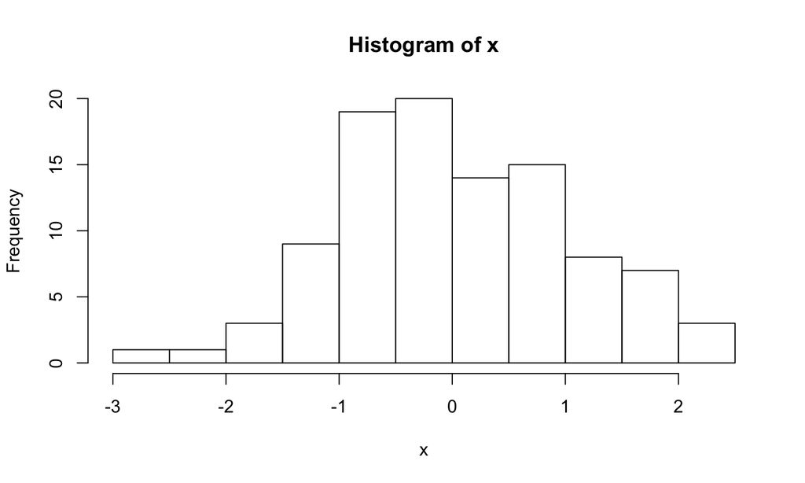

```r
hist(x)
```

## Histogram of y

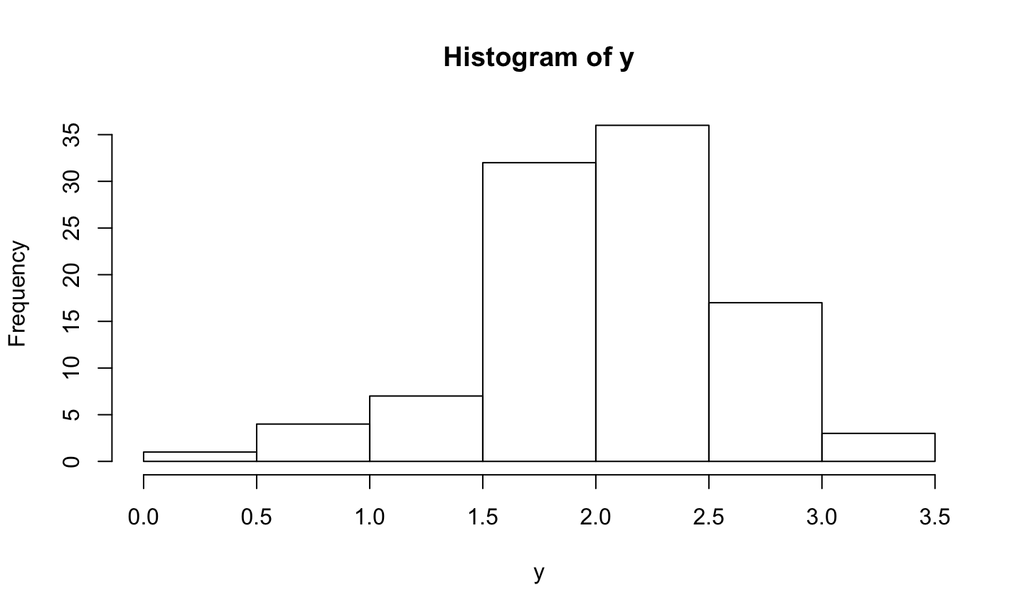

```r
hist(y)
```

## Embed figure saved locally

`<img src="../img/my-img.jpg" height=500px>`

height parameter is optional, but useful.

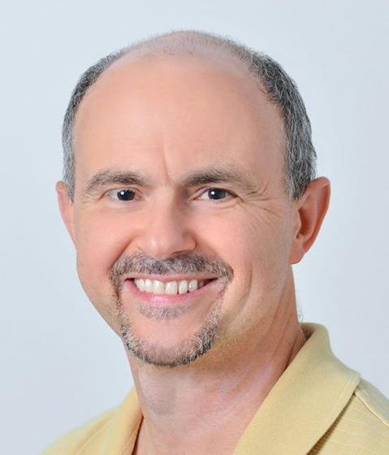

## Embed figure from the web

`<img src="http://cdn.abclocal.go.com/content/wpvi/images/cms/280434_1280x720.jpg" width=900px>`

[figure not shown]

## Embed YouTube video

`<iframe width="420" height="315" src="https://www.youtube.com/embed/9hUy9ePyo6Q" frameborder="0" allowfullscreen></iframe>`

- YouTube gives you code to cut and paste.

[video not shown]

## Printing computed variables

```r
summ.x = summary(x)
summ.y = summary(y)
names(summ.x) # Figure out variable names for indexing
```

```
## [1] "Min."    "1st Qu." "Median"  "Mean"    "3rd Qu." "Max."
```

*Index by variable name:* X lies within the range of [-2.679, 2.301].

*Index by numeric index:* The (y-x) difference in means is `2.01454`.

*Calculate and report:* The correlation between x and y is 0.1074581.